# Homework 8: Fitting Models to Data

Statistical Computing, 36-350

Week of Monday July 23, 2018

Name: Gabriel Krotkov Andrew ID: gkrotkov Collaborated with: Steve Kim

# Reading in, exploring wage data

- **1a.** A data table of dimension 3000 x 11, containing demographic and economic variables measured on individuals living in the mid-Atlantic region, is up at https://raw.githubusercontent.com/linnylin92/36-350_public/master/dat/wage.csv. (This has been adapted from the book [An Introduction to Statistical Learning](http://www-bcf.usc.edu/~gareth/ISL/).) Load this data table into your R session with `read.csv()` and save the resulting data frame as `wage.df`. Check that `wage.df` has the right dimensions, and display its first 3 rows. Hint: the first several lines of the linked file just explain the nature of the data; open up the file (either directly in your web browser or after you download it to your computer), and count how many lines must be skipped before getting to the data; then use an appropriate setting for the `skip` argument to `read.csv()`.

```r
url <- "https://raw.githubusercontent.com/linnylin92/36-350_public/master/dat/wage.csv"
wage.df <- read.csv(url, skip = 15, header = TRUE)

cat("Dimension check, expect TRUE TRUE:\n")
```

```
## Dimension check, expect TRUE TRUE:
```

```r
dim(wage.df) == c(3000, 11)
```

```
## [1] TRUE TRUE
```

```r
head(wage.df, 3)
```

```
##        year age     sex           maritl     race       education
## 231655 2006  18 1. Male 1. Never Married 1. White    1. < HS Grad
## 86582  2004  24 1. Male 1. Never Married 1. White 4. College Grad
## 161300 2003  45 1. Male       2. Married 1. White 3. Some College
##                    region       jobclass         health health_ins
## 231655 2. Middle Atlantic  1. Industrial      1. <=Good      2. No
## 86582  2. Middle Atlantic 2. Information 2. >=Very Good      2. No
## 161300 2. Middle Atlantic  1. Industrial      1. <=Good     1. Yes
##             wage
## 231655  75.04315
## 86582   70.47602
## 161300 130.98218
```

- **1b.** Identify all of the factor variables in `wage.df`, set up a plotting grid of appropriate dimensions, and then plot each of these factor variables, with appropriate titles. What do you notice about the distributions?

```r
cat("Printing out the structure of wage.df, which I will use to identify factors")
```

```
## Printing out the structure of wage.df, which I will use to identify factors
```

```r
cat("\n ---------------------------------------------- \n")
str(wage.df)
```

```
## 'data.frame':    3000 obs. of  11 variables:
##  $ year      : int  2006 2004 2003 2003 2005 2008 2009 2008 2006 2004 ...
##  $ age       : int  18 24 45 43 50 54 44 30 41 52 ...
##  $ sex       : Factor w/ 1 level "1. Male": 1 1 1 1 1 1 1 1 1 1 ...
##  $ maritl    : Factor w/ 5 levels "1. Never Married",..: 1 1 2 2 4 2 2 1 1 2 ...
##  $ race      : Factor w/ 4 levels "1. White","2. Black",..: 1 1 1 3 1 1 4 3 2 1 ...
##  $ education : Factor w/ 5 levels "1. < HS Grad",..: 1 4 3 4 2 4 3 3 3 2 ...
##  $ region    : Factor w/ 1 level "2. Middle Atlantic": 1 1 1 1 1 1 1 1 1 1 ...
##  $ jobclass  : Factor w/ 2 levels "1. Industrial",..: 1 2 1 2 2 2 1 2 2 2 ...
##  $ health    : Factor w/ 2 levels "1. <=Good","2. >=Very Good": 1 2 1 2 1 2 2 1 2 2 ...
##  $ health_ins: Factor w/ 2 levels "1. Yes","2. No": 2 2 1 1 1 1 1 1 1 1 ...
##  $ wage      : num  75 70.5 131 154.7 75 ...
```

```r
cat("----------------------------------------------- \n")
```

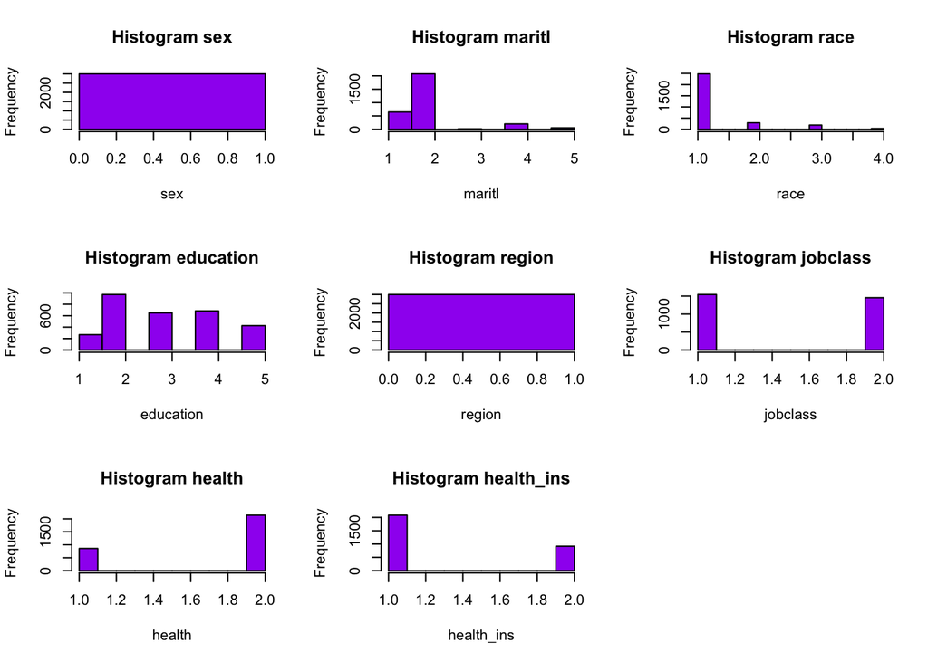

```r
par(mfrow = c(3, 3))
for(i in 1:ncol(wage.df)){
  if(is.factor(wage.df[,i])){
    hist(as.numeric(wage.df[,i]), col = "purple",
         main = paste("Histogram",colnames(wage.df)[i], sep = " "),
         xlab = colnames(wage.df)[i])
  }
}
```

# Linear regression modeling

- **2a.** Fit a linear regression model, using `lm()`, with response variable `wage` and predictor variables `year` and `age`, using the `wage.df` data frame. Call the result `wage.lm`. Display the coefficient estimates, using `coef()`, for `year` and `age`. Do they have the signs you would expect, i.e., can you explain their signs? Display a summary, using `summary()`, of this linear model. Report the standard errors and p-values associated with the coefficient estimates for `year` and `age`. Do both of these predictors appear to be significant, based on their p-values?

```r
wage.lm <- lm(wage ~ year + age, data = wage.df)

coef(wage.lm)
```

```
##   (Intercept)          year           age
## -2318.5309186     1.1968236     0.6992032
```

```r
cat("-------------------------------------\n")
summary(wage.lm)
```

```
##
## Call:
## lm(formula = wage ~ year + age, data = wage.df)
##
## Residuals:
##     Min      1Q  Median      3Q     Max
## -96.766 -25.081  -6.108  16.838 209.053
##
## Coefficients:
##               Estimate Std. Error t value Pr(>|t|)
## (Intercept) -2318.5309   739.1385  -3.137  0.00172 **
## year            1.1968     0.3685   3.247  0.00118 **
## age             0.6992     0.0647  10.808  < 2e-16 ***
## ---
## Signif. codes:  0 '***' 0.001 '**' 0.01 '*' 0.05 '.' 0.1 ' ' 1
##
## Residual standard error: 40.86 on 2997 degrees of freedom
## Multiple R-squared:  0.04165,    Adjusted R-squared:  0.04101
## F-statistic: 65.12 on 2 and 2997 DF,  p-value: < 2.2e-16
```

Answer: They signs are as expected; positive because both covariates have a positive relationship with wage - it makes intuitive sense. Values for year: Standard Error: 0.3685 p: 0.00118 Values for age: Standard Error: 0.0647 p: approx. 2 * 10^-16

- **2b.** Save the standard errors of `year` and `age` into a vector called `wage.se`, and print it out to the console. Don’t just type the values in you see from `summary()`; you need to determine these values programmatically. Hint: define `wage.sum` to be the result of calling `summary()` on `wage.lm`; then figure out what kind of R object `wage.sum` is, and how you can extract the standard errors.

```r
wage.sum <- summary(wage.lm)
startInd <- (nrow(wage.sum$coefficients) + 1)
endInd <- 2*nrow(wage.sum$coefficients)
wage.se <- wage.sum$coefficients[startInd:endInd]
```

[output not shown]

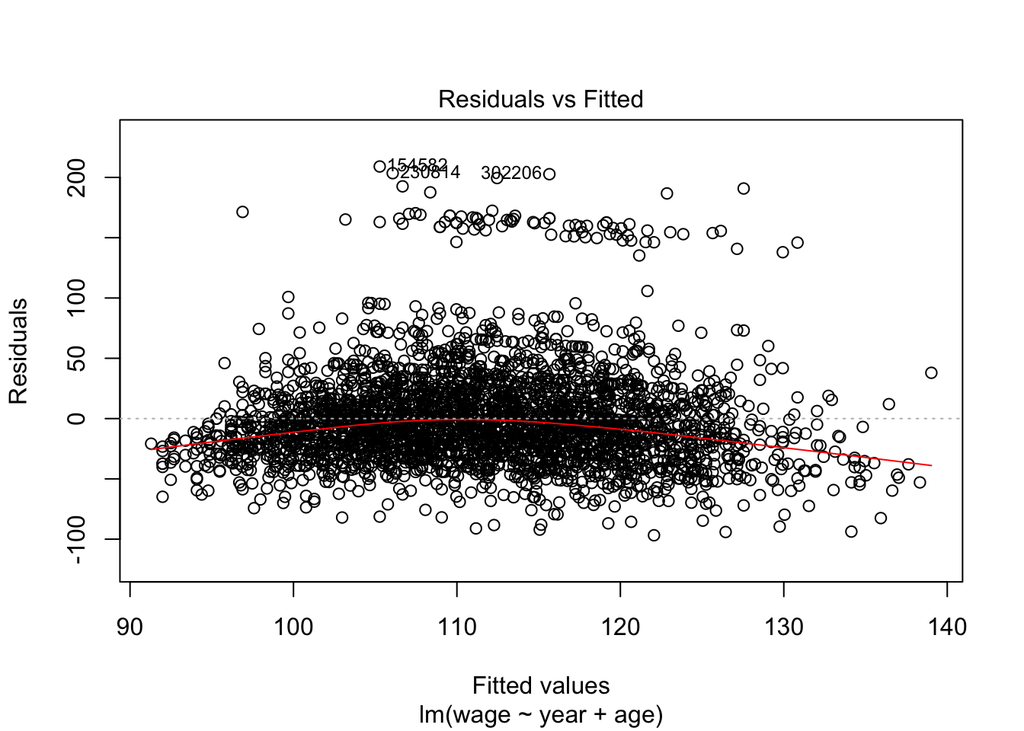

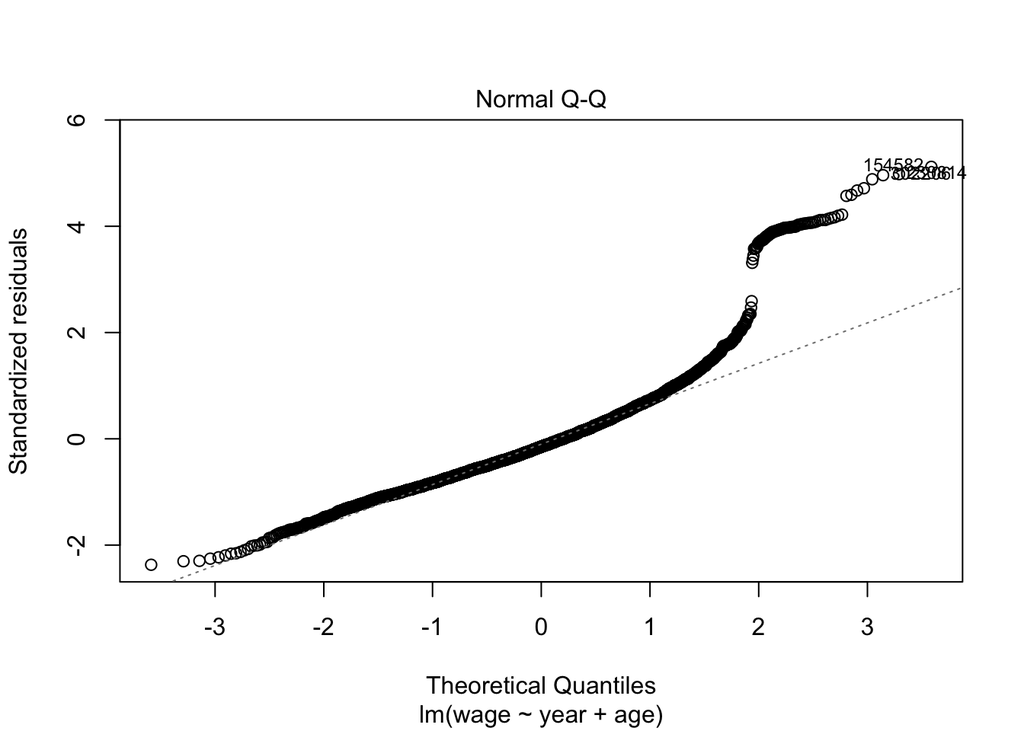

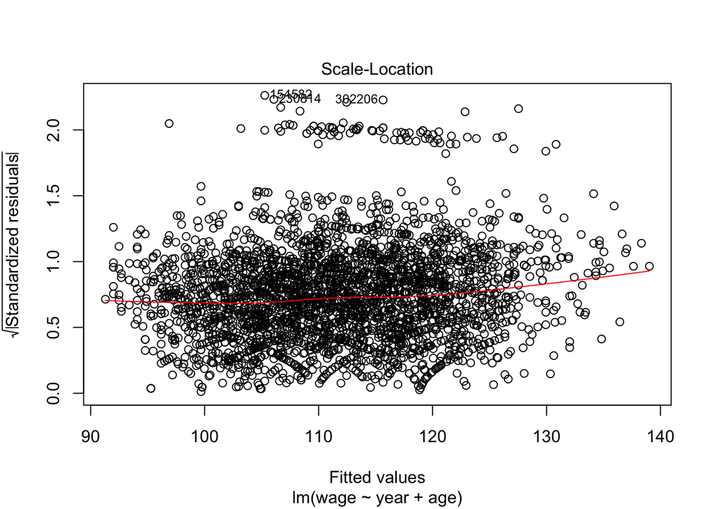

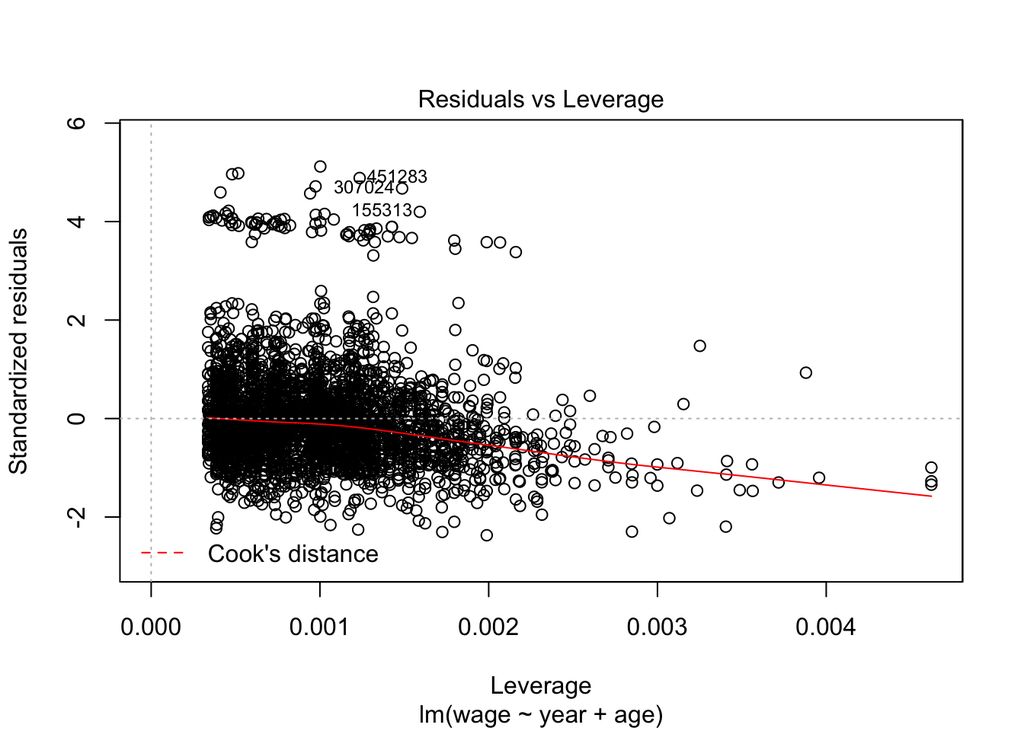

```r
plot(wage.lm)
```

Answer: The normal Q-Q plot is wildly indicative of nonnormality, and the residual plots all indicate nonlinearity.

- **2e.** Use your fitted linear model `wage.lm` to predict: (a) what a 30 year old person should be making this year; (b) what President Trump should be making this year; (c) what you should be making 5 years from now. Comment on the results—which do you think is the most accurate prediction?

```r
cat("A 30-year old should be making approximately:\n",
    predict(wage.lm, newdata = data.frame(year = 2018, age = 30)), "\n")
```

```
## A 30-year old should be making approximately:
##  117.6353
```

```r
cat("President Trump should be making approximately:\n",
     predict(wage.lm, newdata = data.frame(year = 2018, age = 72)), "\n")
```

```
## President Trump should be making approximately:
##  147.0018
```

```r
cat("In five years, I should make approximately:\n",
     predict(wage.lm, newdata = data.frame(year = 2023, age = 24)), "\n")
```

```
## In five years, I should make approximately:
##  119.4242
```

Based on the assumption exploration, prediction (a) is likely to be the most accurate.

# Logistic regression modeling

- **3a.** Fit a logistic regression model, using `glm()` with `family="binomial"`, with the response variable being the indicator that `wage` is larger than 250, and the predictor variables being `year` and `age`. Call the result `wage.glm`. Note: you can set this up in two different ways: (i) you can manually define a new column (say) `wage.high` in the `wage.df` data frame to be the indicator that the `wage` column is larger than 250; or (ii) you can define an indicator variable “on-the-fly” in the call to `glm()` with an appropriate usage of `I()`. Display a summary, reporting the coefficient estimates for `year` and `age`, their standard errors, and associated p-values. Are the predictors `year` and `age` both significant?

```r
wage.glm <- glm(I(wage.df$wage > 250) ~ year + age,
                data = wage.df, family = "binomial")

summary(wage.glm)
```

```
##
## Call:
## glm(formula = I(wage.df$wage > 250) ~ year + age, family = "binomial",
##     data = wage.df)
##
## Deviance Residuals:
##     Min       1Q   Median       3Q      Max
## -0.4039  -0.2542  -0.2198  -0.1899   2.9302
##
## Coefficients:
##               Estimate Std. Error z value Pr(>|z|)
## (Intercept) -48.808462 112.375762  -0.434 0.664047
## year          0.021806   0.056033   0.389 0.697155
## age           0.032779   0.009817   3.339 0.000841 ***
## ---
## Signif. codes:  0 '***' 0.001 '**' 0.01 '*' 0.05 '.' 0.1 ' ' 1
##
## (Dispersion parameter for binomial family taken to be 1)
##
##     Null deviance: 730.53  on 2999  degrees of freedom
## Residual deviance: 719.08  on 2997  degrees of freedom
## AIC: 725.08
##
## Number of Fisher Scoring iterations: 6
```

Answer: In this regression `year` is not significant, but `age` is.

- **3b.** Refit a logistic regression model with the same response variable as in the last question, but now with predictors `year`, `age`, and `education`. Note that the third predictor is stored as a factor variable, which we call a **categorical variable** (rather than a continuous variable, like the first two predictors) in the context of regression modeling. Display a summary. What do you notice about the predictor `education`: how many coefficients are associated with it in the end? **Challenge**: can you explain why the number of coefficients associated with `education` makes sense?

```r
wage.glm <- glm(I(wage.df$wage > 250) ~ year + age + education,
                data = wage.df, family = "binomial")
summary(wage.glm)
```

```
##
## Call:
## glm(formula = I(wage.df$wage > 250) ~ year + age + education,
##     family = "binomial", data = wage.df)
##
## Deviance Residuals:
##     Min       1Q   Median       3Q      Max
## -0.6917  -0.2450  -0.1325  -0.0954   3.3037
##
## Coefficients:
##                               Estimate Std. Error z value Pr(>|z|)
## (Intercept)                 -39.113218 662.234193  -0.059   0.9529
## year                          0.009165   0.057277   0.160   0.8729
## age                           0.026768   0.010791   2.481   0.0131 *
## education2. HS Grad          14.283263 652.196203   0.022   0.9825
## education3. Some College     15.068105 652.196159   0.023   0.9816
## education4. College Grad     16.137982 652.196084   0.025   0.9803
## education5. Advanced Degree  17.356990 652.196068   0.027   0.9788
## ---
## Signif. codes:  0 '***' 0.001 '**' 0.01 '*' 0.05 '.' 0.1 ' ' 1
##
## (Dispersion parameter for binomial family taken to be 1)
##
##     Null deviance: 730.53  on 2999  degrees of freedom
## Residual deviance: 615.76  on 2993  degrees of freedom
## AIC: 629.76
##
## Number of Fisher Scoring iterations: 18
```

Answer: The `education` variable is broken into 4 different indicators comparing to a baseline. This number makes sense because there are 5 levels of `education`, so we need four binary variables to represent all possible levels of the categorical variable. Notable that `education` doesn’t seem to be predictive at all!

- **3c.** In general, one must be careful fitting a logistic regression model on categorial predictors. In order for logistic regression to make sense, for each level of the categorical predictor, we should have observations at this level for which the response is 0, and observations at this level for which the response is 1. In the context of our problem, this means that for each level of the `education` variable, we should have people at this education level that have a wage less than or equal to 250, and also people at this education level that have a wage above 250. Which levels of `education` fail to meet this criterion? Let’s call these levels “incomplete”, and the other levels “complete”.

```r
# Initialize my variables
wage.df$wage_indicator <- as.numeric(wage.df$wage > 250)
completion_mat <- matrix(0, 5, 3)
rownames(completion_mat) <- levels(wage.df$education)
colnames(completion_mat) <- c("Low Wage", "High Wage", "Completion")

# Detect whether instances occur in each category
for(i in 1:nrow(completion_mat)){
  level <- wage.df$education == levels(wage.df$education)[i]
  completion_mat[i, 1] <- (sum(wage.df[level,ncol(wage.df)] == 0) > 0)
  completion_mat[i, 2] <- (sum(wage.df[level,ncol(wage.df)] == 1) > 0)
}

completion_mat[,3] <- completion_mat[,1] * completion_mat[,2]
completion <- completion_mat[,3]
```

[output not shown]

- **3d.** Refit the logistic regression model as in Q3b, with the same response and predictors, but now throwing out all data in `wage.df` that corresponds to the incomplete education levels (equivalently, using only the data from the complete education levels). Display a summary, and comment on the differences seen to the summary for the logistic regression model fitted in Q3b. Did any predictors become more significant, according to their p-values?

```r
wage.filtered <- wage.df[completion[wage.df$education] > 0,]
wage.glm.filtered <- glm((wage.filtered$wage > 250) ~ year + age + education,
                         data = wage.filtered,
                         family = "binomial")

summary(wage.glm.filtered)
```

```
##
## Call:
## glm(formula = (wage.filtered$wage > 250) ~ year + age + education,
##     family = "binomial", data = wage.filtered)
##
## Deviance Residuals:
##     Min       1Q   Median       3Q      Max
## -0.6917  -0.2547  -0.1435  -0.1055   3.3037
##
## Coefficients:
##                               Estimate Std. Error z value Pr(>|z|)
## (Intercept)                 -24.829955 114.867312  -0.216 0.828861
## year                          0.009165   0.057277   0.160 0.872866
## age                           0.026768   0.010791   2.481 0.013118 *
## education3. Some College      0.784841   0.588306   1.334 0.182181
## education4. College Grad      1.854719   0.498254   3.722 0.000197 ***
## education5. Advanced Degree   3.073726   0.475777   6.460 1.04e-10 ***
## ---
## Signif. codes:  0 '***' 0.001 '**' 0.01 '*' 0.05 '.' 0.1 ' ' 1
##
## (Dispersion parameter for binomial family taken to be 1)
##
##     Null deviance: 715.54  on 2731  degrees of freedom
## Residual deviance: 615.76  on 2726  degrees of freedom
## AIC: 627.76
##
## Number of Fisher Scoring iterations: 8
```

Answer: All of the education predictors became more significant, and the significance of the other (quantitative) variables did not change.

# Debt data set

Data on GDP growth and the debt-to-GDP ratio for twenty countries around the world, between the 1940s to 2010, is available at https://raw.githubusercontent.com/linnylin92/36-350_public/master/dat/debt.csv. Note that not every country has data for the same years, and some years in the middle of the period are missing data for some countries but not others.

# Average GDP growth rates

- **4a.** Read this data into your R session, call the resulting data frame `debt.df`, check that it has dimension 1171 x 4, and display its first 4 rows.

```r
url <- "https://raw.githubusercontent.com/linnylin92/36-350_public/master/dat/debt.csv"
debt.df <- read.csv(url)

cat("Dimension check, expect TRUE TRUE:\n")
```

```
## Dimension check, expect TRUE TRUE:
```

```r
dim(debt.df) == c(1171, 4)
```

```
## [1] TRUE TRUE
```

```r
head(debt.df, 4)
```

```
##     Country Year    growth    ratio
## 1 Australia 1946 -3.557951 190.4191
## 2 Australia 1947  2.459475 177.3214
## 3 Australia 1948  6.437534 148.9298
## 4 Australia 1949  6.611994 125.8287
```

- **4b.** Load the `plyr` package into your R session with `library(plyr)`. Use `daply()` to calculate the average GDP growth rate for each country in `debt.df` (averaging over years). Then use `ddply()` and `dlply()` to calculate the same results, but just in different formats. Do not display the entire output of the calls to `ddply()` and `dlply()`; just display the first 5 rows/elements.

```r
library(plyr)

avg_gdp_growth <- function(country){
  return(mean(country$growth))
}

head(daply(debt.df, .(Country), avg_gdp_growth), 5)
```

```
## Australia   Austria   Belgium    Canada   Denmark
##  3.721597  4.438030  3.176287  3.652017  2.656741
```

```r
head(ddply(debt.df, .(Country), avg_gdp_growth), 5)
```

```
##     Country       V1
## 1 Australia 3.721597
## 2   Austria 4.438030
## 3   Belgium 3.176287
## 4    Canada 3.652017
## 5   Denmark 2.656741
```

```r
head(dlply(debt.df, .(Country), avg_gdp_growth), 5)
```

```
## $Australia
## [1] 3.721597
##
## $Austria
## [1] 4.43803
##
## $Belgium
## [1] 3.176287
##
## $Canada
## [1] 3.652017
##
## $Denmark
## [1] 2.656741
```

- **4c.** Show how the same result as in the last question can be computed with one of the built-in apply functions in R.

```r
tapply(debt.df$growth, debt.df$Country, mean)
```

```
##   Australia     Austria     Belgium      Canada     Denmark     Finland
##    3.721597    4.438030    3.176287    3.652017    2.656741    3.571897
##      France     Germany      Greece     Ireland       Italy       Japan
##    3.776350    3.314818    2.927692    3.933766    3.252528    4.447166
## Netherlands New Zealand      Norway    Portugal       Spain      Sweden
##    3.031161    3.069408    3.826671    4.002797    3.196547    3.065083
##          UK          US
##    2.414808    2.997120
```

- **4d.** Now use `daply()` to calculate average GDP growth rate for each year in `debt.df` (averaging over countries). Check that the average growth rates for 1972 and 1989 are 5.629986 and 3.186842, respectively. Then, plot the average growth rate versus the year. Label the axes and title the plot appropriately. What does the general trend appear to be?

```r
growth_by_year <- daply(debt.df, .(Year), avg_gdp_growth)

cat("Correctness check, expect 5.629986, 3.186842:\n")
```

```
## Correctness check, expect 5.629986, 3.186842:
```

```r
growth_by_year[c("1972", "1989")]
```

```
##     1972     1989
## 5.629986 3.186842
```

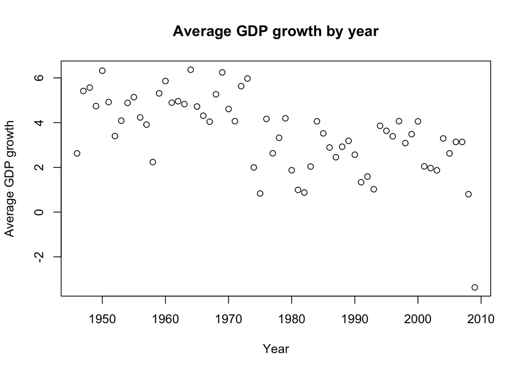

```r
plot(names(growth_by_year), growth_by_year,
     main = "Average GDP growth by year",
     xlab = "Year", ylab = "Average GDP growth")
```

Answer: The general trend appears to be slight negative slope.

- **Challenge.** Using just one line of code, in which you call one of the `d*ply()` functions, create a matrix whose entries are GDP growth by year (rows) and country (columns). Check that it has dimension 64 x 20. Show the first 6 rows and 6 columns.

```r
result <- daply(debt.df, .(Year, Country), avg_gdp_growth)
dim(result)
```

```
## [1] 64 20
```

```r
head(result, 6)
```

```
##       Country
## Year   Australia   Austria   Belgium    Canada   Denmark  Finland   France
##   1946 -3.557951        NA        NA -1.026046        NA 8.132124       NA
##   1947  2.459475        NA 15.216302  4.425837        NA 2.324528       NA
##   1948  6.437534 27.329193 11.440554  1.832761        NA 7.928714       NA
##   1949  6.611994 18.902439 -1.306629  2.174728        NA 6.066839       NA
##   1950  6.920201 12.408962  5.641317  7.375920 7.9458545 3.844582 7.494005
##   1951  4.272612  6.839935  7.033063  5.673231 0.6677008 8.503900 6.134969
##       Country
## Year   Germany Greece   Ireland    Italy Japan Netherlands New Zealand
##   1946      NA     NA        NA       NA    NA          NA    7.711320
##   1947      NA     NA 1.8947368       NA    NA          NA   11.932079
##   1948      NA     NA 4.8608090       NA    NA          NA   -9.922099
##   1949      NA     NA 5.2369595       NA    NA          NA   10.787437
##   1950      NA     NA 0.8178952       NA    NA          NA   14.675949
##   1951   9.167     NA 2.5119734 7.465582    NA          NA   -7.635102
##       Country
## Year      Norway Portugal      Spain    Sweden        UK          US
##   1946 10.201270       NA  4.1562497 11.399403 -2.458310 -10.9421586
##   1947 13.562973       NA  1.9840148  7.936645 -1.276224  -0.8983372
##   1948  6.951517       NA  0.2819504  2.315780  2.924110   4.3972749
##   1949  2.667090       NA -0.0167943  2.949126  3.314717  -0.5123503
##   1950  4.870087 2.837293  2.0570026  6.007847  3.181459   8.7439692
##   1951  5.417767       NA  9.2057478  2.977128  2.727819   7.7318046
```

```r
tail(result, 6)
```

[output not shown]

[output cut: 17 more lines]

# Calculating standard errors

- **5a.** In a plot like that from Q4d, we might ask: how certain are we of individual yearwise averages? To address this, it is useful to plot “error bars” on top of each average. To this end, calculate the standard error of the average GDP growth rates for each year in `debt.df`. To be precise, if $\bar{x}$ is the average of numbers $x_1,\ldots,x_n$, then the standard error of $\bar{x}$ is defined to be $\hat\sigma/\sqrt{n}$, where $\hat\sigma$ is the standard deviation of $x_1,\ldots,x_n$. Your calculation of standard errors should use one of the `plyr` functions, e.g., no `for()` loops allowed. Check that the standard errors for 1972 and 1989 are 0.5440091 and 0.3912434, respectively.

```r
year_se <- daply(debt.df, .(Year),
                 function(year){
                   return((sd(year$growth)) / sqrt(nrow(year)))
                 })

cat("Correctness check, expect 0.5440091, 0.3912434:\n")
```

```
## Correctness check, expect 0.5440091, 0.3912434:
```

```r
year_se[c("1972", "1989")]
```

```
##      1972      1989
## 0.5440091 0.3912434
```

- **5b.** Reproduce your plot from Q4d of average GDP growth rates versus years in `debt.df` but now on top of each point—denoting an average growth rate for a particular year—draw a vertical line segment through this point, extending from the average growth rate minus one standard error to the average growth rate plus one standard error. Hint: use `segments()`. Make sure that these line segments do not extend past the y limits on your plot.

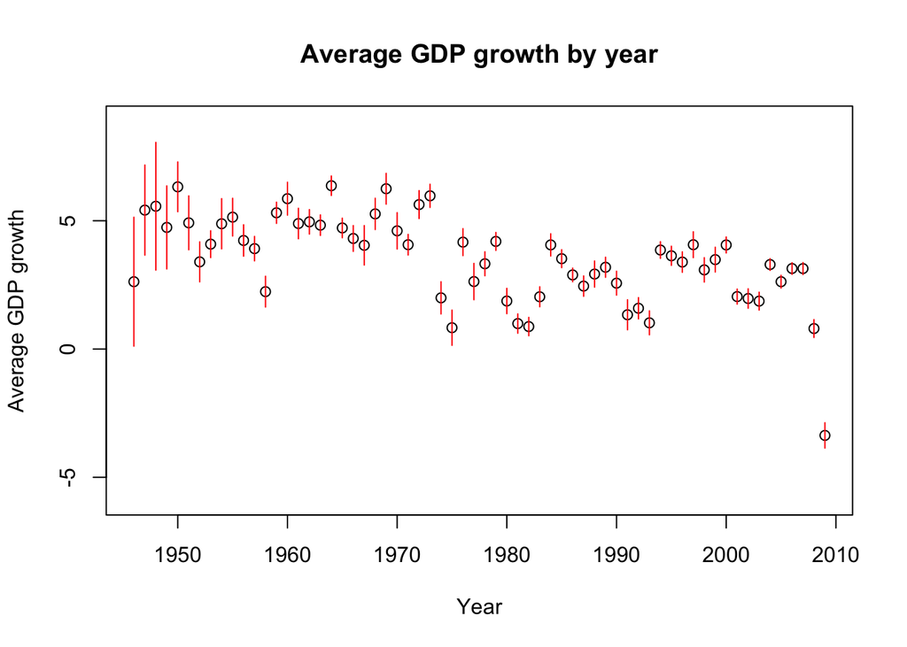

```r
plot(names(growth_by_year), growth_by_year,
     main = "Average GDP growth by year",
     xlab = "Year", ylab = "Average GDP growth",
     ylim = c((min(growth_by_year) - max(year_se)),
              (max(growth_by_year) + max(year_se))))
segments(as.numeric(names(year_se)), (growth_by_year - year_se),
         as.numeric(names(year_se)), (growth_by_year + year_se),
         col = "red")
```

# Economists: which ones are right?

- **6a.** Some economists claim that high levels of government debt leads to slower growth. Other economists claim that low economic growth just propagates forward. The debt data lets us relate (say) this year’s debt to this year’s growth rate; but to investigate economists’ claims, we need to relate this year’s debt to next year’s growth. First, create a new data frame `debt.df.france` which contains just the rows of `debt.df` for France. Check that it has dimension 54 rows and 4 columns, and display its first 5 rows.

```r
debt.df.france <- debt.df[debt.df$Country == "France",]
cat("Dimension check, expect TRUE TRUE:\n")
```

```
## Dimension check, expect TRUE TRUE:
```

```r
dim(debt.df.france) == c(54, 4)
```

```
## [1] TRUE TRUE
```

```r
head(debt.df.france, 5)
```

```
##     Country Year   growth    ratio
## 371  France 1950 7.494005 27.41989
## 372  France 1951 6.134969 22.84359
## 373  France 1952 2.627430 23.49749
## 374  France 1953 2.918587 25.78166
## 375  France 1954 4.825871 24.76863
```

- **6b.** Create a new column in `debt.df.france`, called `next.growth`, which gives next year’s growth if the next year is in the data frame, or NA if the next year is missing. Make sure that your construction of the `next.growth` column is entirely programmatic, i.e., nothing “by hand”, so you should be determining programmatically if the next year is in the data frame. Hint: you may rely on the fact that the rows of the data frame are sorted by years. To check your answers, `next.growth` for 1971 should be 5.885827, but for 1972 it should be NA.

```r
debt.df.france$next.growth <- vector(length = nrow(debt.df.france))
for(i in 1:nrow(debt.df.france)){
  if(i == nrow(debt.df.france)){
    debt.df.france$next.growth[i] <- NA
  }
  else{
    if(debt.df.france$Year[i] + 1 == debt.df.france$Year[i+1]){
      debt.df.france$next.growth[i] <- debt.df.france$growth[i + 1]
    }
    else{
       debt.df.france$next.growth[i] <- NA
    }
  }
}

cat("Check next.growth, expect 5.885827, NA:\n")
```

```
## Check next.growth, expect 5.885827, NA:
```

```r
debt.df.france[debt.df.france$Year == 1971,ncol(debt.df.france)]
```

```
## [1] 5.885827
```

```r
debt.df.france[debt.df.france$Year == 1972,ncol(debt.df.france)]
```

```
## [1] NA
```

- **6c.** Add a `next.growth` column, as you did in the last question, but now to the whole `debt.df` data frame. Hint: write a function to encapsulate what you did in the last question, and then use `ddply()`. Show the first 3 and last 3 rows of the modified `debt.df` data frame.

```r
concatenate_next_growth <- function(df){
  df$next.growth <- vector(length = nrow(df))
  for(i in 1:nrow(df)){
    if(i == nrow(df)){
      df$next.growth[i] <- NA
    }
    else{
      if(df$Year[i] + 1 == df$Year[i+1]){
        df$next.growth[i] <- df$growth[i + 1]
      }
      else{
       df$next.growth[i] <- NA
      }
    }
  }
  return(df)
}

debt.df <- ddply(debt.df, .(Country), concatenate_next_growth)

head(debt.df, 3)
```

```
##     Country Year    growth    ratio next.growth
## 1 Australia 1946 -3.557951 190.4191    2.459475
## 2 Australia 1947  2.459475 177.3214    6.437534
## 3 Australia 1948  6.437534 148.9298    6.611994
```

```r
tail(debt.df, 3)
```

```
##      Country Year     growth    ratio next.growth
## 1169      US 2007  2.1416131 63.98549   0.4381663
## 1170      US 2008  0.4381663 74.09106  -2.7301699
## 1171      US 2009 -2.7301699 83.48283          NA
```

- **6d.** Plot next year’s GDP growth against this year’s debt ratio, over all the data in `debt.df`, with appropriate axes labels and an appropriate title. Report the coefficients from regressing next year’s growth rate on the current year’s debt ratio, again over all the data in `debt.df`. Add this regression line to your plot. Then (separately) plot next year’s GDP growth against the current year’s GDP growth. Similarly, report the coefficients from regressing next year’s growth rate onto this year’s growth rate, and add this regression line to your plot. Can you tell, from comparing the latter two regressions, whether current growth or current debt is a better predictor of future growth?

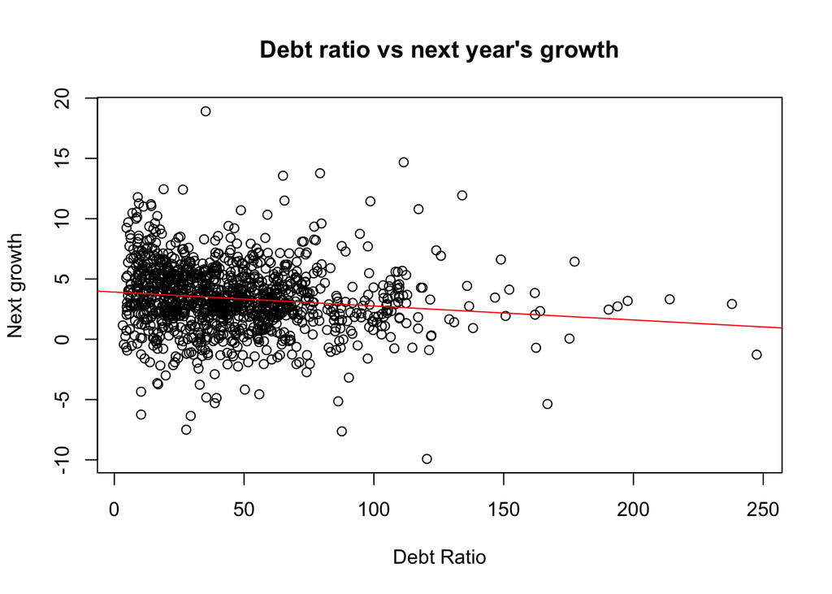

```r
plot(debt.df$ratio, debt.df$next.growth,
     main = "Debt ratio vs next year's growth",
     xlab = "Debt Ratio", ylab = "Next growth")

debt.lm <- lm(next.growth ~ ratio, data = debt.df)
abline(debt.lm, col = "red")
```

```r
cat("Coefficients of the debt linear regression")
```

```
## Coefficients of the debt linear regression
```

```r
coef(debt.lm)
```

```
## (Intercept)       ratio
##  3.92472155 -0.01160842
```

```r
plot(debt.df$growth, debt.df$next.growth,
     main = "Current growth vs next year's growth",
     xlab = "Current growth", ylab = "Next growth")

growth.lm <- lm(next.growth ~ growth, data = debt.df)
cat("Coefficients of the growth linear regression")
```

```
## Coefficients of the growth linear regression
```

```r
coef(growth.lm)
```

```
## (Intercept)      growth
##   1.9710648   0.4006517
```

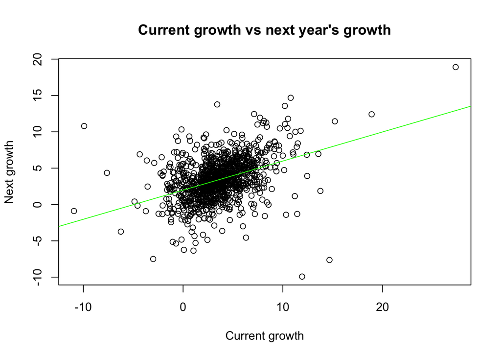

```r
abline(growth.lm, col = "green")
```

Answer: Debt appears to have an almost-zero slope correlating it to next year’s growth, while last year’s growth is more aggressively related. Exploring r^2 values and p-values would be valuable for further insight, but based on just this information last year’s growth appears to be the better predictor.

- **Challenge.** Add a new column called `delta.growth` to the `debt.df` data frame, giving the difference between next year’s GDP growth rate and this year’s GDP growth rate. Then, report the coefficients from regressing the change in GDP growth on the current GDP growth rate and the current debt-to-GDP ratio, over all the data in `debt.df`.

  Some economists have claimed that there is a “tipping point”, or even a “point of no return”, when the ratio of government debt-to-GDP crosses 90%, above which growth slows dramatically or even becomes negative. Add an indicator column `high.debt` to the `debt.df` data frame, that takes the value TRUE when the debt-to-GDP ratio is over 90% and FALSE otherwise. Now regress the change in GDP growth on the current GDP growth rate, the current debt-to-GDP ratio, as well as the indicator that the debt is above 90%. Report the coefficients. What does the coefficient of the indicator variable `high.debt` tell you about the claim?

```r
debt.df$delta.growth <- debt.df$next.growth - debt.df$growth
debt.df$high.debt <- debt.df$ratio > 90

tipping_point_lm <- lm(delta.growth ~ growth + ratio + high.debt,
                       data = debt.df)
coef(tipping_point_lm)
```

```
##   (Intercept)        growth         ratio high.debtTRUE
##   2.371374981  -0.610797458  -0.009103703   0.655072690
```

Answer: The coefficient of the `high.debt` variable indicates that, if there is an effect relating the >90% debt indicator variable with the `growth` response (valuable to investigate p-value to explore that), that it amounts to approximately .65 units of `delta.growth` in total on average.